# Final Project Advanced Modeling

Mafalda González González

2025-06-18

# Supervised learning: Climate Change Perceptions

Climate change remains one of the most pressing challenges of our time, demanding not only systemic policy reforms and technological solutions, but also widespread public engagement. As European society tries transitions to a low-carbon economy, understanding public perceptions and behaviours regarding climate change is essential. This project uses data from the European Social Survey (ESS) Round 8 (2016), which provides a rich cross-national dataset capturing individuals’ attitudes, beliefs, and behaviours related to climate change and energy use across Europe.

The aim of this project is to apply supervised machine learning techniques of classification and regression to investigate key public attitudes.

We use a subset of the ESS Round 8 dataset (DOI: 10.21338/ess8e02_3), which includes over 30,000 respondents and covers a wide range of demographic, political, and environmental variables.

# Pre-processing data

Before starting the actual analysis, we load our libraries, download and clean our datasets and take a look at their compositions.

## Library

```r
# delete everything
rm(list=ls())

library(tidyverse)
library(dplyr)
library(readr) # read csv
library(tibble)

library(gt) # tables
library(patchwork) # plots position

# pre-processing
library(countries) # matching country names
library(mice) # NAs

# descriptive
library(DataExplorer)
library(skimr)

# models
library(caret)
library(ggeffects) # comparing predictors for models
library(pROC) # roc curve
library(MASS) # lda
library(rpart) # decision trees
library(rpart.plot)
library(MLmetrics) # random forest
library(pdp) # partial dependence plots

# regression models
library(olsrr) # subset selection of regression model
library(elasticnet) # ridge, lasso, elastic
```

## Input gathering

### ESS8

For data on climate change perceptions, we use survey data structured at the individual level from the [European Social Survey (ESS) Round 8 (2016)](https://ess.sikt.no/en/study/f8e11f55-0c14-4ab3-abde-96d3f14d3c76), specifically the module “Climate Change and Energy”, which provides insights into public attitudes, beliefs and concerns towards climate change, energy security, personal and group norms, responsibility, and policy preferences across 23 European countries. We focus on variables related to:

- perceived causes and consequences of climate change,
- individual and governmental responsibility,
- willingness to act or pay, and
- trust in renewable vs non-renewable energy sources.

The ESS8 dataset is well-suited for analysing attitudes toward climate change because of its cross-national scope, high methodological rigour, and detailed climate and energy module. It also allows us to link individual attitudes to sociodemographic and political variables, enabling multivariate analysis.

```r
ess <- read_csv("ESS8e02_3.csv")
```

### World Bank

To enrich our analysis with contextual economic information, we integrate country-level data from the [World Bank’s DataBank](https://databank.worldbank.org/source/world-development-indicators/Type/TABLE/preview/on) on World Development Indicators (WDI). These variables were retrieved by building a customised dataset using the World Bank DataBank export tool. Specifically, we use:

- GDP per capita (as a proxy for national wealth), and
- Gini index (as a measure of income inequality).

The inclusion of these variables will allow for a deeper exploration of how economic factors can influence individuals’ attitudes towards climate change and their willingness to support environmental policies. This helps us assess whether support for environmental policies is shaped not only by individual attitudes, but also by national economic context.

```r
wdi <- read_csv("wdi_data.csv")
```

## Cleaning and joining

Below we take a look at the variables we have selected and rename them, clean the datasets and prepare them for joining.

### Selected variables

In the **ESS8 climate-related module** we select the following general and climate related variables:

Selected Variables from the ESS8 Dataset

| Renamed_var | Original_var | Meaning |
| --- | --- | --- |
| country | cntry | Country name in full |
| female | gndr | Gender with female = 1 |
| age | agea | Age |
| energy_eff_appliance | eneffap | How likely to buy most energy-efficient home appliance |
| confidence_less_energy | cflsenr | How confident you could use less energy than now |
| worry_powercuts | wrpwrct | How worried are you there may be power cuts in country |
| worry_expense_energy | wrenexp | How worried are you that energy may be too expensive for many people in country |
| worry_depend_fossil | wrdpfos | How worried are you about your country being too dependent on fossil fuels like oil, gas and coal |
| worry_energy_weather | wrntdis | How worried are you that energy supplies could be interrupted by natural disasters or extreme weather |
| worry_cc | wrclmch | How worried are you about climate change |
| cc_real | clmchng | Do you think the world's climate is changing |
| cc_causes | ccnthum | Do you think climate change is caused by natural processes, human activity, or both |
| cc_impact | ccgdbd | How good or bad do you think the impact of climate change will be on people across the world (0 = extremely bad, 10 = extremely good) |
| cc_personal_resp | ccrdprs | To what extent do you feel a personal responsibility to try to reduce climate change |
| cc_red_personal | ownrdcc | How likely do you think it is that limiting your own energy use would help reduce climate change |
| cc_red_group | lkredcc | How likely do you think it is that large-scale reduction in energy use would reduce climate change |
| gov_action | gvsrdcc | How likely do you think governments in enough countries will take action to reduce climate change |
| taxes_fossil | inctxff | To what extent are you in favour or against increasing taxes on fossil fuels to reduce climate change |
| subsidise_renew_energy | sbsrnen | To what extent are you in favour or against using public money to subsidise renewable energy (e.g., wind and solar) |

We also have the variables elgcoal, elgngas, elgnuc, elgsun, elgwind and elghydr. We will work with these variables in the feature engineering process.

Out of the **general ESS8 dataset** we also export these political and demographic variables:

Political and Sociodemographic Variables from ESS8

| Renamed_var | Original_var | Meaning |
| --- | --- | --- |
| voted | vote | Did you vote in the last national election in your country? |
| boycotted | bctprd | During the last 12 months, have you boycotted certain products? |
| ideology | lrscale | Political self-placement on a left (0) to right (10) scale |
| life_satisfaction | stflife | Overall life satisfaction (0 = extremely dissatisfied, 10 = extremely satisfied) |
| important_env | impenv | Believes it is important to care for nature and the environment |
| important_trad | imptrad | Values tradition and following customs handed down by religion or family |
| edu_years | eduyrs | Years of education completed |

```r
ess_recode <- ess %>%
  dplyr::select(
    # general variables
    idno, cntry, gndr, agea,

    # climate change
    eneffap, cflsenr, elgcoal, elgngas, elghydr, elgnuc, elgsun, elgwind, elgbio, wrpwrct, wrenexp, wrdpfos, wrntdis, clmchng, ccnthum, ccrdprs, wrclmch, ccgdbd, lkredcc, gvsrdcc, ownrdcc, inctxff, sbsrnen,

    # political variables
    psppsgva, vote, bctprd, lrscale, stflife, impenv, imptrad,

    # sociodemographics
    eduyrs
  )

# RENAMING: code book
# general variables
ess_recode <- ess_recode %>%
  mutate(
    # country
    country = country_name(cntry, to = "simple", verbose = TRUE, poor_matches = TRUE),
    # gender
    female = case_when(
      gndr == 1 ~ 0,
      gndr == 2 ~ 1, # female
      TRUE ~ NA),
    #age
    age = if_else(agea == 999, NA_real_, agea)
  )
```

```
##
## In total 23 unique country names were provided
## 23/23 have been matched with EXACT matching
## 0/23 have been matched with FUZZY matching
```

```r
# climate change
ess_recode <- ess_recode %>%
  mutate(
    energy_eff_appliance = if_else(eneffap > 10, NA, eneffap), # eneffap - How likely to buy most energy efficient home appliance
    confidence_less_energy = if_else(cflsenr > 10, NA, cflsenr), # How confident you could use less energy than now
    worry_powercuts = if_else(wrpwrct > 5, NA, wrpwrct), # How worried are you there may be power cuts in country
    worry_expense_energy = if_else(wrenexp > 5, NA, wrenexp),# How worries are you that the energy may be too expensive for many people in country
    worry_depend_fossil = if_else(wrdpfos > 5, NA, wrdpfos), # How worried are you about [country] being too dependent on using energy generated by fossil fuels such as oil, gas and coal?
    worry_energy_weather = if_else(wrntdis > 5, NA, wrntdis), # How worried are you that energy supplies could be interrupted by natural disasters or extreme weather
    cc_real = case_when(
      clmchng == 1 ~ 4,
      clmchng == 2 ~ 3,
      clmchng == 3 ~ 2,
      clmchng == 4 ~ 1,
      TRUE ~ NA_real_), # Do you think the world's climate is changing
    cc_causes = case_when(
      ccnthum < 3 ~ "Natural",
      ccnthum == 3 ~ "Both",
      ccnthum == 4 | ccnthum == 5 ~ "Human",
      ccnthum == 55 ~ "No CC",
      TRUE ~ NA), # Do you think that climate change is caused by natural processes, human activity, or both
    cc_personal_resp = if_else(ccrdprs > 10, NA, ccrdprs), # To what extent do you feel a personal responsibility to try to reduce climate change
    worry_cc = if_else(wrclmch > 5, NA, wrclmch), #How worried are you about climate change
    cc_impact = if_else(ccgdbd > 10, NA, ccgdbd), # How good or bad do you think the impact of climate change will be on people across the world? Please choose a number from 0 to 10, where 0 is extremely bad and 10 is extremely good
    cc_red_group = if_else(lkredcc > 10, NA, lkredcc), # Now imagine that large numbers of people limited their energy use. How likely do you think it is that this would reduce climate change?
    gov_action = if_else(gvsrdcc > 10, NA, gvsrdcc), # how likely do you think it is that governments in enough countries will take action that reduces climate change?
    cc_red_personal = if_else(ownrdcc > 10, NA, ownrdcc), # How likely do you think it is that limiting your own energy use would help reduce climate change?
    taxes_fossil = case_when(
      inctxff == 5 ~ 1, # strongly against
      inctxff == 4 ~ 2,
      inctxff == 2 ~ 4,
      inctxff == 1 ~ 5, # strongly in favour
      TRUE ~ NA_real_), # To what extent are you in favour or against the following policies in [country] to reduce climate change? Increasing taxes on fossil fuels, such as oil, gas and coal
    subsidise_renew_energy = case_when(
      sbsrnen == 5 ~ 1, # strongly against
      sbsrnen == 4 ~ 2,
      sbsrnen == 2 ~ 4,
      sbsrnen == 1 ~ 5, # strongly in favour
      TRUE ~ NA_real_), # To what extent are you in favour or against the following policies in [country] to reduce climate change? Using public money to subsidise renewable energy such as wind and solar power.
  )

# political variables
ess_recode <- ess_recode %>%
  mutate(
    voted = case_when(
      vote == 1 ~ 1, # YES voted
      vote == 2 ~ 0,
      TRUE ~ NA_real_), # Did you vote in the last [country] national election in [month/year]?
    boycotted = case_when(
      bctprd == 1 ~ 1, # YES boycotted
      bctprd == 2 ~ 0,
      TRUE ~ NA_real_), # During the last 12 months, have you done any of the following? Have youboycotted certain products?
    ideology = if_else(lrscale > 10, NA, lrscale), # In politics people sometimes talk of 'left' and 'right'. Using this card, where would you place yourself on this scale, where 0 means the left and 10 means the right?
    life_satisfaction = if_else(stflife > 10, NA, stflife), # All things considered, how satisfied are you with your life as a whole nowadays? Please answer using this card, where 0 means extremely dissatisfied and 10 means extremely satisfied.
    important_env = if_else(impenv > 6, NA, impenv),
    important_env = case_when(
      important_env < 3 ~ 3, # high identification
      important_env == 3 | important_env == 4 ~ 2, # moderate identification
      important_env > 4 ~ 1), # low identification
      # She/he strongly believes that people should care for nature. Looking after the environment is important to her/him.
    important_trad = if_else(imptrad > 6, NA, imptrad),
    important_trad = case_when(
      important_trad < 3 ~ 3, # high identification
      important_trad == 3 | important_trad == 4 ~ 2, # moderate identification
      important_trad > 4 ~ 1), # low identification
    # Tradition is important to her/him. She/he tries to follow the customs handed down by her/his religion or her/his family.
  )

# sociodemographics
ess_recode <- ess_recode %>%
  mutate(
    edu_years = if_else(eduyrs > 76, NA, eduyrs) # About how many years of education have you completed
  )

ess_clean <- ess_recode %>%
  dplyr::select(
    country, female, age, energy_eff_appliance, confidence_less_energy, worry_powercuts, worry_expense_energy, worry_depend_fossil, worry_energy_weather, cc_real, cc_causes, cc_personal_resp, worry_cc, cc_impact, cc_red_group, gov_action, cc_red_personal, taxes_fossil, subsidise_renew_energy, voted, boycotted, ideology, life_satisfaction, important_env, important_trad, edu_years, elgsun, elgwind, elghydr, elgcoal, elgngas, elgnuc
  )
```

Out of the World Bank’s DataBank we export the GDP per capita and Gini index, as well as the country.

Economic Variables from World Bank Data

| Renamed_var | Original_var | Meaning |
| --- | --- | --- |
| country | Country Name | Country |
| gdp_per_capita | GDP per capita (constant 2015 US$) [NY.GDP.PCAP.KD] | GDP per capita as a proxy for national wealth |
| gini | Gini index [SI.POV.GINI] | Gini index as a measure of income inequality |

```r
wdi_recode <- wdi %>%
  dplyr::select(
    `Country Name`, `GDP per capita (constant 2015 US$) [NY.GDP.PCAP.KD]`, `Gini index [SI.POV.GINI]`
  ) %>%
  rename(
    country = `Country Name`,
    gdp_per_capita = `GDP per capita (constant 2015 US$) [NY.GDP.PCAP.KD]`,
    gini = `Gini index [SI.POV.GINI]`
  ) %>%
  drop_na(country) %>%
  mutate(
    country = country_name(country, to = "simple", verbose = TRUE, poor_matches = TRUE)
  )
```

```
##
## In total 23 unique country names were provided
## 23/23 have been matched with EXACT matching
## 0/23 have been matched with FUZZY matching
```

Finally, we make sure the variables have been correctly saved.

```r
str(ess_clean)
```

```
## tibble [44,387 × 32] (S3: tbl_df/tbl/data.frame)
##  $ country               : chr [1:44387] "Austria" "Austria" "Austria" "Austria" ...
##  $ female                : num [1:44387] 1 0 1 0 1 1 1 1 1 1 ...
##  $ age                   : num [1:44387] 34 52 68 54 20 65 52 44 22 41 ...
##  $ energy_eff_appliance  : num [1:44387] 8 10 9 10 10 8 6 10 8 7 ...
##  $ confidence_less_energy: num [1:44387] 10 3 3 7 10 7 5 7 7 8 ...
##  $ worry_powercuts       : num [1:44387] 2 1 3 2 1 3 1 2 2 3 ...
##  $ worry_expense_energy  : num [1:44387] 3 2 4 2 1 3 1 3 2 3 ...
##  $ worry_depend_fossil   : num [1:44387] 4 3 3 2 3 NA 1 3 2 2 ...
##  $ worry_energy_weather  : num [1:44387] 2 1 3 3 1 3 2 3 1 2 ...
##  $ cc_real               : num [1:44387] 4 4 4 3 4 3 3 4 3 3 ...
##  $ cc_causes             : chr [1:44387] "Human" "Human" "Human" "Both" ...
##  $ cc_personal_resp      : num [1:44387] 8 7 8 6 6 5 0 8 7 7 ...
##  $ worry_cc              : num [1:44387] 4 4 4 3 4 3 2 4 2 3 ...
##  $ cc_impact             : num [1:44387] 10 2 2 7 5 5 5 3 4 5 ...
```

[output cut: 18 more lines]

```r
unique(ess_clean$country)
```

```
##  [1] "Austria"            "Belgium"            "Switzerland"
##  [4] "Czechia"            "Germany"            "Estonia"
##  [7] "Spain"              "Finland"            "France"
## [10] "United Kingdom"     "Hungary"            "Ireland"
## [13] "Israel"             "Iceland"            "Italy"
## [16] "Lithuania"          "Netherlands"        "Norway"
## [19] "Poland"             "Portugal"           "Russian Federation"
## [22] "Sweden"             "Slovenia"
```

```r
str(wdi_recode)
```

```
## tibble [23 × 3] (S3: tbl_df/tbl/data.frame)
##  $ country       : chr [1:23] "Austria" "Belgium" "Switzerland" "Czechia" ...
##  $ gdp_per_capita: num [1:23] 44363 41173 84611 18359 42528 ...
##  $ gini          : num [1:23] 30.8 27.6 33 25.4 31.4 31.2 35.8 27.1 31.9 30.3 ...
```

```r
unique(wdi_recode$country)
```

```
##  [1] "Austria"            "Belgium"            "Switzerland"
##  [4] "Czechia"            "Germany"            "Estonia"
##  [7] "Spain"              "Finland"            "France"
## [10] "Hungary"            "Israel"             "Italy"
## [13] "Netherlands"        "Poland"             "Russian Federation"
## [16] "Slovenia"           "United Kingdom"     "Ireland"
## [19] "Iceland"            "Lithuania"          "Norway"
## [22] "Portugal"           "Sweden"
```

### Joining datasets

Now, having standardized the names in both datasets with the function `country_name` from the package `countries`, we can simply join the datasets by their countries. In both datasets all countries were matched perfectly to the official country names, and both datasets have 23 countries present. This is because the WorldBank dataset was exported only selecting the countries of the ESS8. The intersect of the `country` variable of the two datasets confirms this. We can join without a problem.

```r
intersect(unique(ess_clean$country), unique(wdi_recode$country))
```

```
##  [1] "Austria"            "Belgium"            "Switzerland"
##  [4] "Czechia"            "Germany"            "Estonia"
##  [7] "Spain"              "Finland"            "France"
## [10] "United Kingdom"     "Hungary"            "Ireland"
## [13] "Israel"             "Iceland"            "Italy"
## [16] "Lithuania"          "Netherlands"        "Norway"
## [19] "Poland"             "Portugal"           "Russian Federation"
## [22] "Sweden"             "Slovenia"
```

```r
data <- ess_clean %>%
  left_join(wdi_recode, by = "country")
```

### Treating NAs

With both datasets cleaned and successfully merged, we now turn to handling missing values in preparation for the descriptive and predictive analyses.

```r
colSums(is.na(data)) / nrow(data) * 100
```

```
##                country                 female                    age
##             0.00000000             0.02027621             0.34920134
##   energy_eff_appliance confidence_less_energy        worry_powercuts
##             2.50298511             2.14477212             0.99578705
##   worry_expense_energy    worry_depend_fossil   worry_energy_weather
##             0.97325794             4.09579381             1.04084529
##                cc_real              cc_causes       cc_personal_resp
##             2.47369725             4.85051930             5.54216325
##               worry_cc              cc_impact           cc_red_group
##             3.90429630             7.10793701             7.33322820
##             gov_action        cc_red_personal           taxes_fossil
##             7.45488544             6.15720819            26.35906910
## subsidise_renew_energy                  voted              boycotted
##            15.50904544             9.36084890             0.48212314
##               ideology      life_satisfaction          important_env
##            13.07590060             0.42129452             1.70996012
##         important_trad              edu_years                 elgsun
##             1.69869556             0.95523464             0.00000000
##                elgwind                elghydr                elgcoal
##             0.00000000             0.00000000             0.00000000
##                elgngas                 elgnuc         gdp_per_capita
##             0.00000000             0.00000000             0.00000000
##                   gini
##             0.00000000
```

To assess which imputations method less significantly alters the data structure, we compare the distribution of the variable `cc_impact` under three scenarios: the original data (with missing values), listwise deletion, and multiple imputation using the `mice` package. The variables `cc_red_personal` and `cc_causes` are excluded from the imputation model, as they will later be used as target variables in our predictive analyses. We choose `cc_impact` for this comparison because it is a representative scale-based variable, has a moderate level of missingness (~7%), and is conceptually central to our topic on climate change perceptions.

In order for the rendering process to work more smoothly, I have saved the mice imputation results and load them as a .rds in the chunk below.

```r
# mice multiple imputation
mice_data <- data

vars_excluded <- mice_data %>%
  dplyr::select(cc_red_personal, cc_causes)

mice_data_impute <- mice_data %>%
  dplyr::select(-cc_red_personal, -cc_causes)
```

```r
pre <- mice(mice_data_impute, m = 5, seed = 123) #defaults
meth <- pre$method
imputed_data <- mice(mice_data_impute, method = meth, m = 5, seed = 123)
data_mice <- complete(imputed_data, action = 5)

saveRDS(data_mice, "data_mice.rds")
```

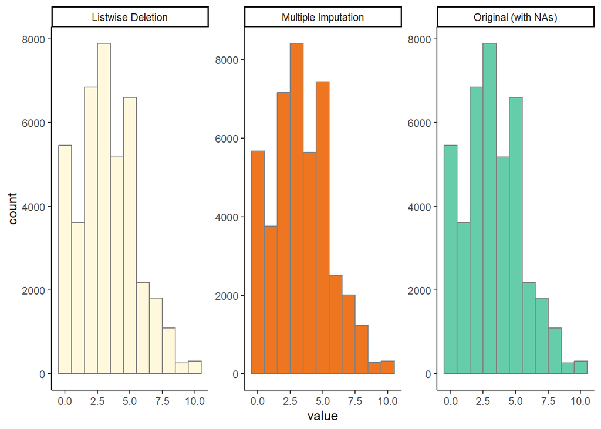

```r
data_mice <- readRDS("data_mice.rds")

# Comparison
df_original <- data.frame(method = "Original (with NAs)", value = data$cc_impact)
df_listwise <- data.frame(method = "Listwise Deletion", value = na.omit(data$cc_impact))
df_imputed <- data.frame(method = "Multiple Imputation", value = data_mice$cc_impact)

impact_long <- bind_rows(df_listwise, df_original, df_imputed)

# plot
ggplot(impact_long, aes(x = value, fill = method)) +
  geom_histogram(binwidth = 1, color = "#808080") +
  facet_wrap(~method, scales = "free_y") +
  scale_fill_manual(values = c("cornsilk", "chocolate2", "aquamarine3")) +
  theme_classic() +
  theme(legend.position = "none")
```

```r
no_na <- data %>%
  drop_na()

no_na %>%
  dim()
```

```
## [1] 20988    34
```

However, a closer inspection of missingness by country reveales that listwise deletion disproportionately affects some countries. While a few countries (e.g., Norway, Sweden) lose fewer than 40% of their observations, others (e.g., Lithuania, the Russian Federation) lose more than 70%. This uneven loss raises concerns about cross-national representativeness, as it may bias results toward countries with lower item nonresponse.

```r
# before deletion
before_counts <- data %>%
  count(country, name = "n_before")

# after deletion
after_counts <- no_na %>%
  count(country, name = "n_after")

# comparison
country_loss <- full_join(before_counts, after_counts, by = "country") %>%
  mutate(
    loss = n_before - n_after,
    pct_loss = round(100 * loss / n_before, 1)
  ) %>%
  arrange(desc(pct_loss))

country_loss
```

```
## # A tibble: 23 × 5
##    country            n_before n_after  loss pct_loss
##    <chr>                 <int>   <int> <int>    <dbl>
##  1 Russian Federation     2430     489  1941     79.9
##  2 Lithuania              2122     596  1526     71.9
##  3 Italy                  2626     871  1755     66.8
##  4 Israel                 2557     937  1620     63.4
##  5 Poland                 1694     665  1029     60.7
##  6 Hungary                1614     670   944     58.5
##  7 Estonia                2019     869  1150     57
##  8 Spain                  1958     903  1055     53.9
##  9 Czechia                2269    1067  1202     53
## 10 Slovenia               1307     637   670     51.3
## # ℹ 13 more rows
```

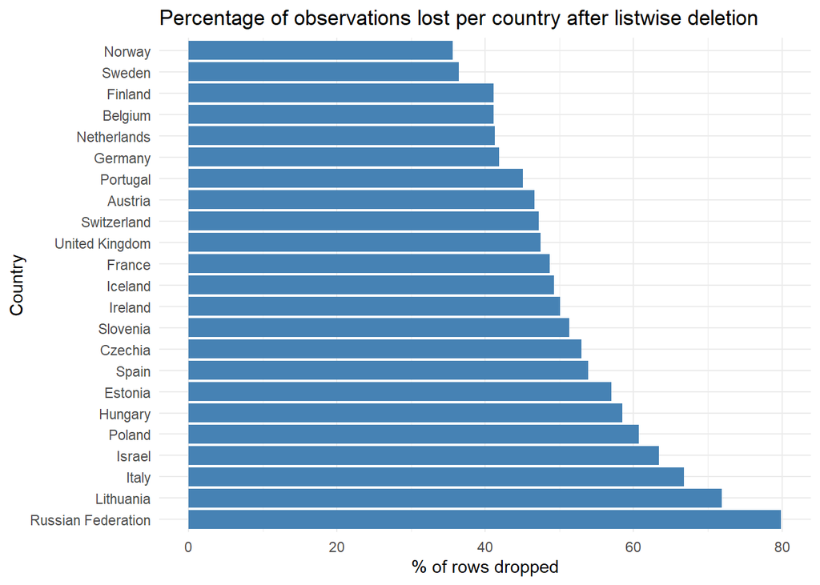

```r
ggplot(country_loss, aes(x = reorder(country, -pct_loss), y = pct_loss)) +
  geom_col(fill = "steelblue") +
  labs(
    title = "Percentage of observations lost per country after listwise deletion",
    x = "Country", y = "% of rows dropped"
  ) +
  theme_minimal() +
  coord_flip()
```

Given these findings, we opt to use multiple imputation via the mice package, which minimises the risk of distorting country-level balance or underrepresenting specific populations.

```r
all.equal(rownames(data_mice), rownames(vars_excluded))  # should be TRUE
```

```
## [1] TRUE
```

```r
data_mice <- bind_cols(data_mice, vars_excluded)

data_clean <- data_mice
dim(data_clean)
```

```
## [1] 44387    34
```

## Feature Engineering

To improve model interpretability and capture meaningful patterns, we apply some feature engineering. These include average preferences for renewable and non-renewable energy sources, an environmental concern index aggregating key climate-related worries, and an interaction term combining personal responsibility with perceived government action. We also define income groups based on GDP per capita.

Constructed Variables for Feature Engineering

| Adjusted_var | Original_vars | Meaning |
| --- | --- | --- |
| preference_renewable | elgsun, elgwind, elghydr | Average support for renewable energy sources (solar, wind, hydro) |
| preference_non_renewable | elgcoal, elgngas, elgnuc | Average support for non-renewable energy sources (coal, gas, nuclear) |
| income_group | gdp_per_capita | Categorical income group based on national GDP per capita (Low to Very High) |
| balance_gov_personal | cc_personal_resp * gov_action | Interaction between personal and government responsibility to reduce climate change |
| env_concern_index | worry_powercuts, worry_expense_energy, worry_depend_fossil, worry_energy_weather | Composite index of environmental concern |

```r
data_eng <- data_clean %>%
  mutate(

    # reverse scale for energy generation preference
    across(c(elgsun, elgwind, elghydr, elgcoal, elgngas, elgnuc),
           ~ case_when(
             . == 1 ~ 5,  # A very large amount
             . == 2 ~ 4,  # A large amount
             . == 3 ~ 3,  # A medium amount
             . == 4 ~ 2,  # A small amount
             . == 5 ~ 1,  # None at all
             TRUE ~ NA_real_
           )),

    # preferences
    preference_renewable = rowMeans(dplyr::select(., elgsun, elgwind, elghydr), na.rm = TRUE),
    preference_non_renewable = rowMeans(dplyr::select(., elgcoal, elgngas, elgnuc), na.rm = TRUE),

    # income group
    income_group = cut(data_clean$gdp_per_capita,
                        breaks = c(0, 5000, 15000, 30000, Inf),
                        labels = c("Low", "Middle", "High", "Very High"),
                        right = FALSE),

    # personal responsibility * government action
    balance_gov_personal = cc_personal_resp * gov_action,

    # environmental concern index
    env_concern_index = rowMeans(.[, c("worry_powercuts", "worry_expense_energy", "worry_depend_fossil", "worry_energy_weather")], na.rm = TRUE)

  )
```

Finally, we are also going to convert our categorical variables into factors.

```r
data_eng <- data_eng %>%
  mutate(
    country = as.factor(country),

    important_env = as.factor(important_env), # 1,2,3
    important_trad = as.factor(important_trad), # 1,2,3

    income_group = as.factor(income_group), # Low, Middle, High, Very High

    female = as.factor(female),
    cc_causes = as.factor(cc_causes)
  )

data <- data_eng
```

## Reducing dataset dimension

Due to the size of the data at this point, I believe that it is reasonable to reduce the dataset in order to be able to work later with some of the machine learning methods, which take more time the larger the dataset is. Hence, we reduce the dataset from over 44,000 observations to approximately 5,000 while maintaining representativeness. We employe a stratified sampling strategy based on our two target variables, by using `cc_causes` as a categorical stratification variable, and we discretised the continuous variable `cc_red_personal` into five quantile-based bins. This approach ensures that the subsample preserves the joint distribution of both targets, which is essential for developing classification and regression models without introducing sampling bias.

```r
data <- data %>%
  mutate(
    subsidy_bin = ntile(cc_red_personal, 5),  # create 5 quantile bins
    causes_factor = as.factor(cc_causes)
  )

set.seed(123)
data_small <- data %>%
  group_by(causes_factor, subsidy_bin) %>%
  sample_frac(size = 5000 / nrow(data)) %>%
  ungroup() %>%
  dplyr::select(-c(subsidy_bin, causes_factor))
```

To validate the representativeness of the subsample, we can compare the distributions of the original and reduced datasets.

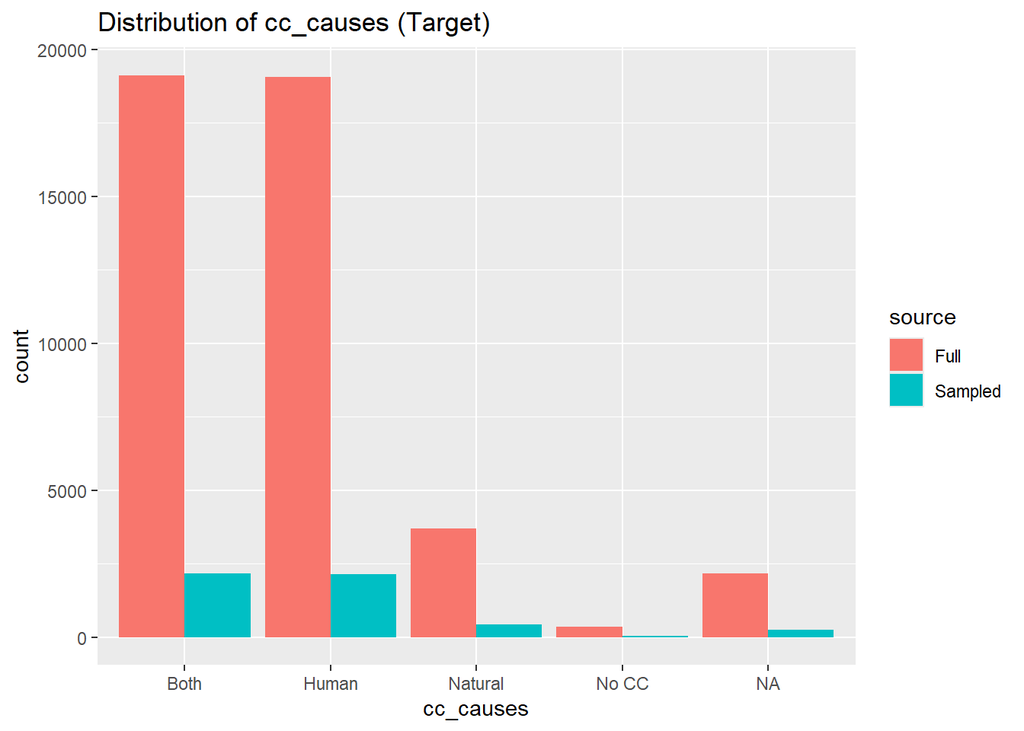

```r
# cc_causes
bind_rows(
  data %>% mutate(source = "Full") %>% dplyr::select(cc_causes, source),
  data_small %>% mutate(source = "Sampled") %>% dplyr::select(cc_causes, source)
) %>%
  ggplot(aes(x = cc_causes, fill = source)) +
  geom_bar(position = "dodge") +
  labs(title = "Distribution of cc_causes (Target)")
```

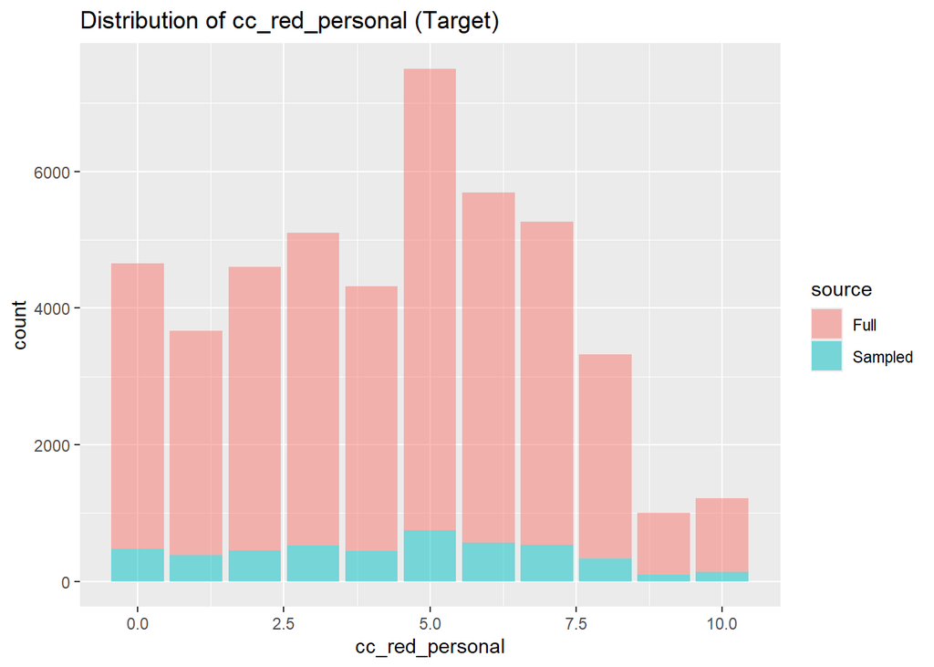

```r
# cc_red_personal
bind_rows(
  data %>% mutate(source = "Full") %>% dplyr::select(cc_red_personal, source),
  data_small %>% mutate(source = "Sampled") %>% dplyr::select(cc_red_personal, source)
) %>%
  ggplot(aes(x = cc_red_personal, fill = source)) +
  geom_bar(alpha = 0.5) +
  labs(title = "Distribution of cc_red_personal (Target)")
```

The bar plot for `cc_causes` and the histogram for `cc_red_personal` indicate that the stratified sample successfully mirrors the distributional shape of the full dataset. While the sample counts are smaller, the proportions seem to match, suggesting that the 5,000-observation subsample retains the diversity and balance of the original data. This makes it suitable for initial modelling and testing without sacrificing representativeness.

# Descriptive analysis

Having cleaned, merged, engineered and reduced our data set, we can proceed to do an exploration of our cleaned dataset to understand the relationships between the variables better.

We first examine the structure of our dataset:

```r
data <- data_small

dim(data)
```

```
## [1] 4999   39
```

```r
glimpse(data)
```

```
## Rows: 4,999
## Columns: 39
## $ country                  <fct> Italy, Italy, Ireland, Czechia, Belgium, Pola…
## $ female                   <fct> 0, 0, 0, 0, 0, 0, 0, 0, 0, 0, 0, 1, 1, 1, 1, …
## $ age                      <dbl> 72, 68, 68, 65, 45, 62, 57, 37, 65, 20, 66, 6…
## $ energy_eff_appliance     <dbl> 10, 9, 10, 9, 2, 7, 4, 9, 10, 9, 10, 10, 7, 6…
## $ confidence_less_energy   <dbl> 8, 5, 10, 8, 10, 7, 4, 9, 9, 10, 2, 0, 5, 5, …
## $ worry_powercuts          <dbl> 2, 3, 5, 2, 1, 1, 1, 2, 2, 1, 2, 4, 2, 1, 4, …
## $ worry_expense_energy     <dbl> 4, 3, 3, 3, 4, 4, 3, 3, 1, 2, 3, 4, 2, 1, 4, …
## $ worry_depend_fossil      <dbl> 4, 4, 4, 3, 1, 2, 3, 3, 2, 3, 2, 4, 2, 1, 4, …
## $ worry_energy_weather     <dbl> 4, 3, 5, 2, 3, 2, 2, 2, 1, 1, 2, 4, 2, 1, 3, …
## $ cc_real                  <dbl> 3, 3, 4, 3, 3, 3, 3, 3, 3, 4, 4, 3, 4, 3, 3, …
## $ cc_personal_resp         <dbl> 7, 2, 0, 1, 0, 5, 6, 5, 5, 7, 0, 5, 1, 1, 4, …
## $ worry_cc                 <dbl> 3, 4, 2, 2, 2, 2, 3, 2, 2, 3, 1, 3, 3, 2, 3, …
## $ cc_impact                <dbl> 4, 4, 6, 5, 5, 4, 5, 5, 8, 4, 2, 5, 4, 2, 4, …
```

[output cut: 26 more lines]

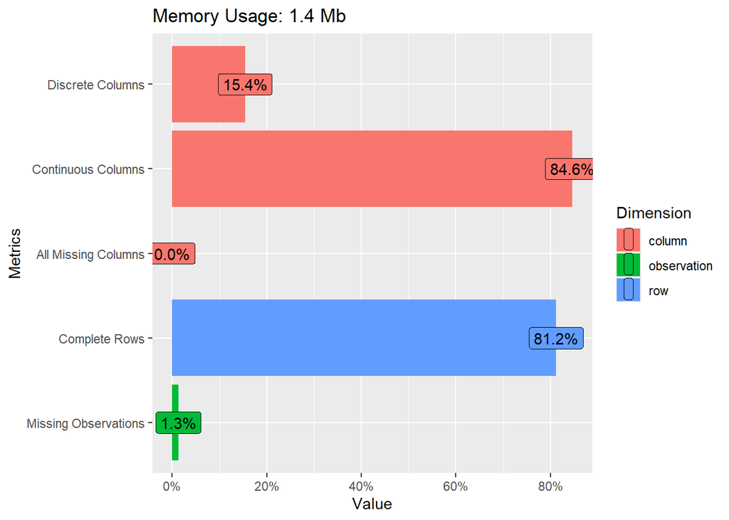

```r
plot_intro(data)
```

We examine pairwise correlations among numeric variables to identify redundancy and assess potential multicollinearity:

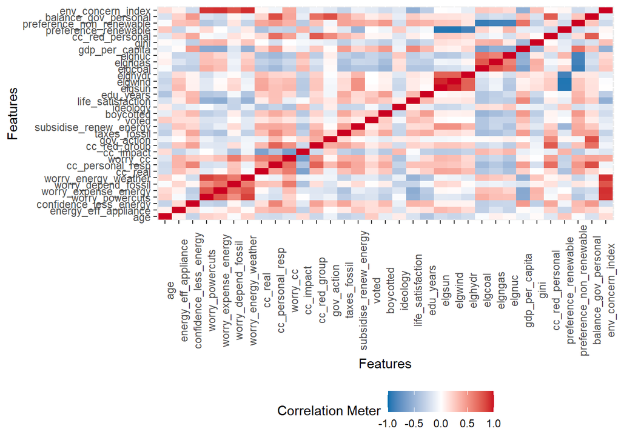

```r
numeric_data <- data %>%
  dplyr::select(where(is.numeric))
corr_matrix <- cor(numeric_data, use = "complete.obs")
plot_correlation(corr_matrix)
```

While this plot lets us understand that there are some variables that seem to be significantly related, it is difficult to read. Hence, we can calculate highly correlated pairs (r > 0.65) and if necessary, we remove redundant predictors to improve model stability.

```r
cor_df <- as.data.frame(as.table(corr_matrix))
subset(cor_df, abs(Freq) > 0.65 & Var1 != Var2)
```

```
##                          Var1                     Var2       Freq
## 132         env_concern_index          worry_powercuts  0.7387728
## 165         env_concern_index     worry_expense_energy  0.7431771
## 198         env_concern_index      worry_depend_fossil  0.6699804
## 231         env_concern_index     worry_energy_weather  0.7474104
## 296      balance_gov_personal         cc_personal_resp  0.6907690
## 428      balance_gov_personal               gov_action  0.7190053
## 690      preference_renewable                   elgsun -0.8236744
## 723      preference_renewable                  elgwind -0.8395721
## 756      preference_renewable                  elghydr -0.6995946
## 790  preference_non_renewable                  elgcoal -0.7128787
## 823  preference_non_renewable                  elgngas -0.6994495
## 856  preference_non_renewable                   elgnuc -0.7098052
## 978                    elgsun     preference_renewable -0.8236744
## 979                   elgwind     preference_renewable -0.8395721
## 980                   elghydr     preference_renewable -0.6995946
## 1014                  elgcoal preference_non_renewable -0.7128787
## 1015                  elgngas preference_non_renewable -0.6994495
## 1016                   elgnuc preference_non_renewable -0.7098052
## 1032         cc_personal_resp     balance_gov_personal  0.6907690
## 1036               gov_action     balance_gov_personal  0.7190053
## 1060          worry_powercuts        env_concern_index  0.7387728
## 1061     worry_expense_energy        env_concern_index  0.7431771
## 1062      worry_depend_fossil        env_concern_index  0.6699804
## 1063     worry_energy_weather        env_concern_index  0.7474104
```

We can see that many of the aggregated variables are correlated with the variables that originally formed them. We prioritize keeping the aggregated variables, hence, we keep for example `env_concern_index` over `worry_powercuts`, `worry_expense_energy`, `worry_depend_fossil` or `worry_energy_weather`. Similarly, we keep `preference_renewable`, `preference_non_renewable` and `balance_gov_personal`.

```r
data <- data %>%
  dplyr::select(-c(worry_powercuts, worry_expense_energy, worry_depend_fossil, worry_energy_weather, cc_personal_resp, gov_action, elgsun, elgwind, elghydr, elgcoal, elgngas, elgnuc))
```

## Distribution of Target Vars

Let us now visualise our two target variables, `cc_red_personal` and `cc_causes`.

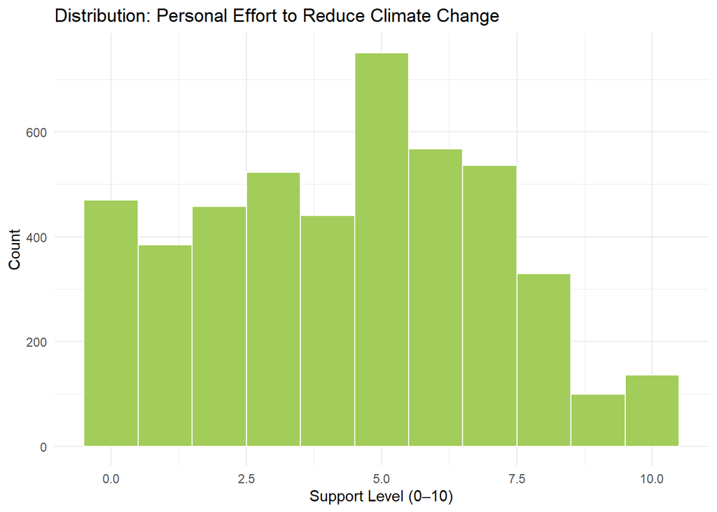

```r
par(mfrow = c(1, 2))

ggplot(data, aes(x = cc_red_personal)) +
  geom_histogram(binwidth = 1, fill = "darkolivegreen3", colour = "white") +
  theme_minimal() +
  labs(title = "Distribution: Personal Effort to Reduce Climate Change",
       x = "Support Level (0–10)", y = "Count")
```

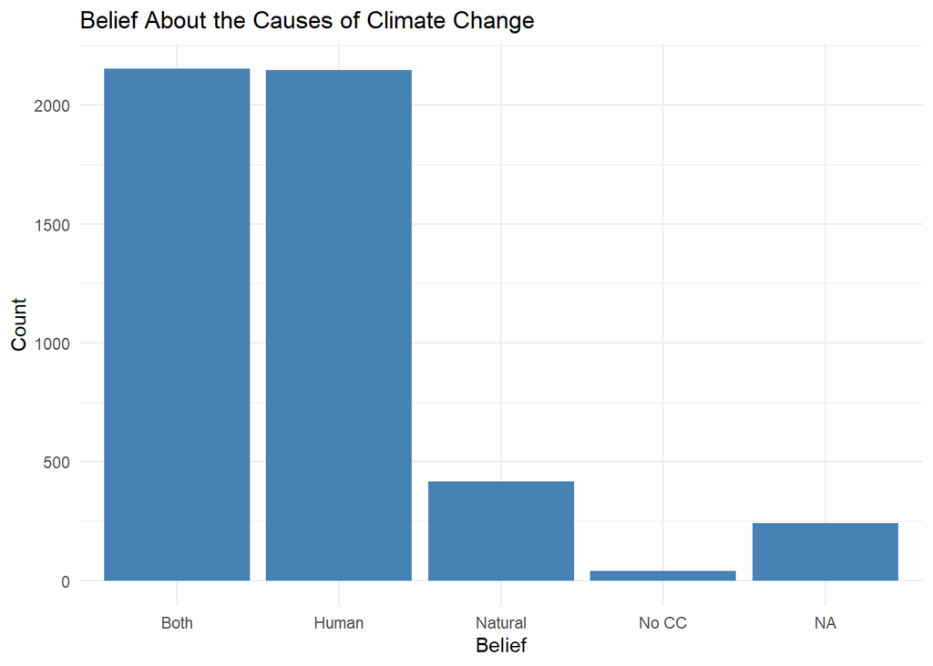

```r
ggplot(data, aes(x = cc_causes)) +
  geom_bar(fill = "steelblue") +
  theme_minimal() +
  labs(title = "Belief About the Causes of Climate Change",
       x = "Belief", y = "Count")
```

```r
par(mfrow = c(1, 1))

data %>%
  count(cc_causes)
```

```
## # A tibble: 5 × 2
##   cc_causes     n
##   <fct>     <int>
## 1 Both       2154
## 2 Human      2147
## 3 Natural     417
## 4 No CC        39
## 5 <NA>        242
```

For `cc_causes`, most respondents believe climate change is either equally caused by natural and human factors (n = 2,154) or caused by human activity (n = 2,147). A smaller proportion attributes it solely to natural causes (n = 417), and very few deny climate change altogether (n = 39). This suggests a moderate consensus around anthropogenic influence.

## Bivariate plots

With bivariate plots we can explore the relation between our target variables and other variables. For example, how belief in personal effort relates to perceptions of government vs personal responsibility and environmental concern. Or also, whether left–right political orientation is associated with beliefs about climate change causes.

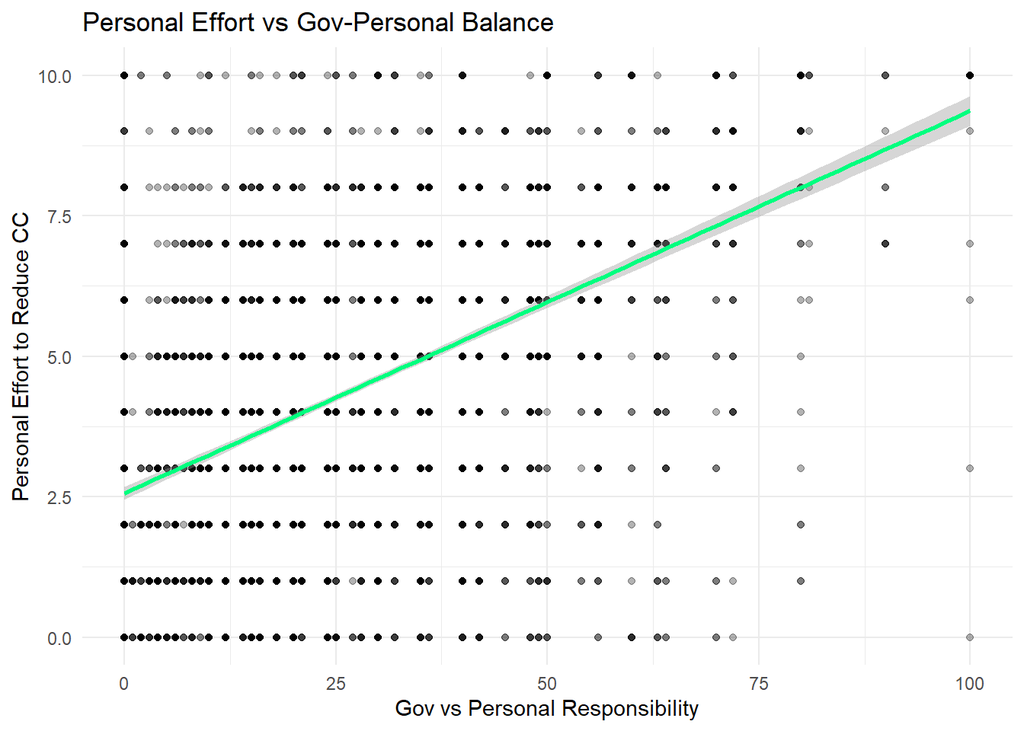

```r
par(mfrow = c(1,2))
# cc_red_personal vs balance_gov_personal
ggplot(data, aes(x = balance_gov_personal, y = cc_red_personal)) +
  geom_point(alpha = 0.3) +
  geom_smooth(method = "lm", colour = "springgreen") +
  labs(title = "Personal Effort vs Gov-Personal Balance",
       x = "Gov vs Personal Responsibility",
       y = "Personal Effort to Reduce CC") +
  theme_minimal()
```

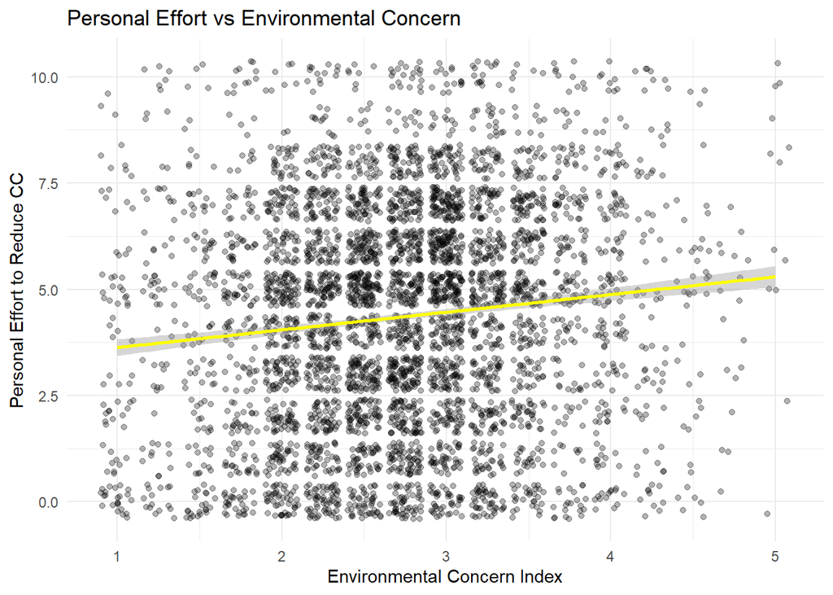

```r
# cc_red_personal vs env_concern_index
ggplot(data, aes(x = env_concern_index, y = cc_red_personal)) +
  geom_jitter(alpha = 0.3) +
  geom_smooth(method = "lm", colour = "yellow") +
  labs(title = "Personal Effort vs Environmental Concern",
       x = "Environmental Concern Index",
       y = "Personal Effort to Reduce CC") +
  theme_minimal()
```

```r
par(mfrow = c(1,1))
```

Even though it seems weird, the dot patterns actually appear grid-like because both variables are measured on discrete, bounded scales (e.g., 0–10 or 1–5), which limits the number of possible value combinations and causes overlapping points to stack in regular intervals. The fact is that predictors are not easily captured in simple bivariate visualisations, as the dataset’s structure constrains the expressiveness of standard exploratory plots. Rather than seeing these limitations as flaws, we approach them as a realistic feature of working with attitudinal survey data.

The first plot shows a strong positive relationship between `balance_gov_personal` and `cc_red_personal.` As individuals shift more responsibility from the government to themselves, their reported willingness to reduce personal energy use increases. This suggests that perceived personal responsibility is a key driver of climate action intentions.

The second plot shows a much weaker association between `env_concern_index` and `cc_red_personal.` Although there is a slight upward trend, the relationship is shallow and dispersed. This may indicate that general environmental concern does not directly translate into concrete willingness to act unless paired with a sense of personal accountability.

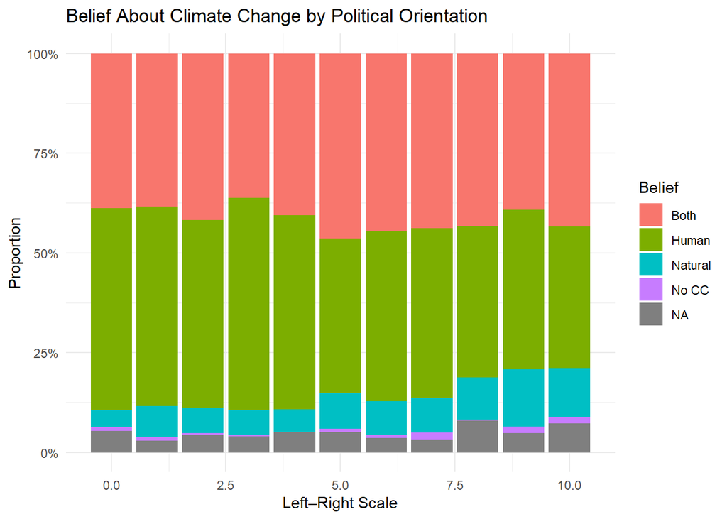

```r
# cc_causes vs ideology
ggplot(data, aes(x = ideology, fill = cc_causes)) +
  geom_bar(position = "fill") +
  scale_y_continuous(labels = scales::percent) +
  labs(title = "Belief About Climate Change by Political Orientation",
       x = "Left–Right Scale", y = "Proportion",
       fill = "Belief") +
  theme_minimal()
```

This plot reveals how beliefs about the causes of climate change vary by political orientation. Respondents on the left of the scale (0–3) are more likely to believe that climate change is caused by both human and natural factors, or by humans alone. As political orientation shifts rightward, there’s a slight increase in scepticism and support for the “natural causes” explanation becomes more visible. However, belief in human or mixed causes remains dominant across the entire scale.

# Classification: Interpretation

In this section we explore a binary classification problem. We want to predict predict whether a respondent believes that climate change is mostly caused by human activity.

To do this, we transform the original variable `cc_causes`, which captures perceptions on the causes of climate change (Human-caused, Natural-caused, Both, No climate change), into a binary target variable `cc_belief`. Respondents who believe climate change is entirely caused by human activity are coded as 1 (believers: human caused), while those who attribute it to natural processes, a mix or are unsure are coded as 0 (non-believers: natural caused, both, no climate change). This dichotomisation aligns with the general population differentiation between individuals who accept the scientific consensus on anthropogenic climate change and those who do not. In preparation for all the tasks ahead, we also do a listwise deletion of all missing values in our target variable of this section.

```r
data_class <- data %>%
  mutate(
    cc_belief = case_when(
      cc_causes == "Human" ~ 1, # clear belief in human causes
      cc_causes %in% c("Natural", "Both", "No CC") ~ 0, # all other views
      TRUE ~ NA_real_
    ),
    cc_belief = factor(cc_belief, labels = c("Non-believer", "Believer"))
  ) %>%
  dplyr::select(-cc_causes) %>%
  filter(!is.na(cc_belief))
cat("Classification data:", nrow(data_class), "observations\n")
```

```
## Classification data: 4757 observations
```

We are now left with 4757 observations.

Further, we are going to manually choose a base-category for the variable `country`. This is because our model is going to compare all countries to a base -category and give us the impact of a country towards believing or not in climate change in relation to that base-category. Hence, to understand what it actually means it is recommendable to first understand the base-category itself.

We do this by calculating the average of Believers in the countries, then comparing the individual countries to the average and choosing the closest to it. Thus, Norway becomes our reference country as seen below.

```r
# avg belief rate
overall_mean <- mean(data_class$cc_belief == "Believer", na.rm = TRUE)

# belief rate by country
country_belief <- data_class %>%
  group_by(country) %>%
  summarise(belief_rate = mean(cc_belief == "Believer", na.rm = TRUE)) %>%
  mutate(distance_to_mean = abs(belief_rate - overall_mean)) %>%
  arrange(distance_to_mean)

ref_country <- country_belief %>%
  slice(1) %>%
  pull(country)

ref_country
```

```
## [1] Norway
## 23 Levels: Austria Belgium Czechia Estonia Finland France Germany ... United Kingdom
```

```r
data_class <-  data_class %>%
  mutate(country = relevel(country, ref = as.character(ref_country)))
```

## Logistic regression

Now we can split the dataset into a training set (75%) and testing set (25%), and compute a logistic regression.

```r
set.seed(123)
in_train <- createDataPartition(data_class$cc_belief, p = 0.75, list = FALSE)
training <- data_class[in_train, ]
testing  <- data_class[-in_train, ]


logit.model <- glm(cc_belief ~ .,
                   family = "binomial",
                   data = training)

summary(logit.model)
```

```
##
## Call:
## glm(formula = cc_belief ~ ., family = "binomial", data = training)
##
## Coefficients: (4 not defined because of singularities)
##                            Estimate Std. Error z value             Pr(>|z|)
## (Intercept)               -2.423064   0.525056  -4.615      0.0000039334526 ***
## countryAustria             1.019461   0.276383   3.689             0.000226 ***
## countryBelgium             0.779916   0.267277   2.918             0.003523 **
## countryCzechia             0.305195   0.270804   1.127             0.259744
## countryEstonia             0.029793   0.280822   0.106             0.915508
## countryFinland             0.620127   0.261802   2.369             0.017851 *
## countryFrance             -0.156686   0.268093  -0.584             0.558921
## countryGermany             0.212939   0.242781   0.877             0.380443
## countryHungary             0.208499   0.295232   0.706             0.480051
## countryIceland             0.327228   0.338493   0.967             0.333684
## countryIreland            -0.323883   0.255064  -1.270             0.204153
## countryIsrael              0.531573   0.261222   2.035             0.041856 *
## countryItaly               0.630022   0.255655   2.464             0.013726 *
## countryLithuania          -0.395067   0.278686  -1.418             0.156306
## countryNetherlands         0.316096   0.262500   1.204             0.228520
## countryPoland             -0.205161   0.285489  -0.719             0.472370
## countryPortugal           -0.146398   0.292199  -0.501             0.616356
## countryRussian Federation  0.011754   0.279865   0.042             0.966500
## countrySlovenia           -0.239235   0.295088  -0.811             0.417523
## countrySpain               0.708070   0.275090   2.574             0.010054 *
## countrySweden              0.322414   0.287192   1.123             0.261589
## countrySwitzerland        -0.074996   0.284095  -0.264             0.791794
## countryUnited Kingdom     -0.067847   0.269809  -0.251             0.801456
## female1                   -0.182126   0.077379  -2.354             0.018588 *
## age                       -0.009689   0.002281  -4.248      0.0000215759937 ***
## energy_eff_appliance       0.015684   0.018094   0.867             0.386065
## confidence_less_energy    -0.019416   0.016431  -1.182             0.237325
## cc_real                    0.322691   0.073946   4.364      0.0000127781591 ***
## worry_cc                   0.333565   0.052714   6.328      0.0000000002485 ***
## cc_impact                 -0.183005   0.019437  -9.415 < 0.0000000000000002 ***
## cc_red_group               0.127206   0.019512   6.519      0.0000000000706 ***
## taxes_fossil               0.098244   0.029340   3.348             0.000813 ***
## subsidise_renew_energy     0.077638   0.038009   2.043             0.041088 *
## voted                     -0.071979   0.096311  -0.747             0.454841
```

[output cut: 13 more lines]

```
## income_groupHigh                 NA         NA      NA                   NA
## income_groupVery High            NA         NA      NA                   NA
## balance_gov_personal       0.004354   0.002483   1.754             0.079481 .
## env_concern_index         -0.189173   0.061650  -3.068             0.002151 **
## ---
## Signif. codes:  0 '***' 0.001 '**' 0.01 '*' 0.05 '.' 0.1 ' ' 1
##
## (Dispersion parameter for binomial family taken to be 1)
##
##     Null deviance: 4763.7  on 3454  degrees of freedom
## Residual deviance: 4133.6  on 3408  degrees of freedom
##   (114 observations deleted due to missingness)
## AIC: 4227.6
##
## Number of Fisher Scoring iterations: 3
```

```r
exp(coef(logit.model))
```

```
##               (Intercept)            countryAustria            countryBelgium
##                0.08864954                2.77170044                2.18128869
##            countryCzechia            countryEstonia            countryFinland
##                1.35688914                1.03024158                1.85916486
##             countryFrance            countryGermany            countryHungary
##                0.85497278                1.23730878                1.23182770
##            countryIceland            countryIreland             countryIsrael
##                1.38711721                0.72333508                1.70160633
##              countryItaly          countryLithuania        countryNetherlands
##                1.87765201                0.67363508                1.37176248
##             countryPoland           countryPortugal countryRussian Federation
##                0.81451646                0.86381370                1.01182326
##           countrySlovenia              countrySpain             countrySweden
##                0.78722970                2.03006927                1.38045660
##        countrySwitzerland     countryUnited Kingdom                   female1
##                0.92774735                0.93440333                0.83349643
##                       age      energy_eff_appliance    confidence_less_energy
##                0.99035738                1.01580722                0.98077099
##                   cc_real                  worry_cc                 cc_impact
##                1.38083807                1.39593600                0.83276429
##              cc_red_group              taxes_fossil    subsidise_renew_energy
##                1.13565144                1.10323187                1.08073157
##                     voted                 boycotted                  ideology
##                0.93055008                0.84962119                0.97522037
##         life_satisfaction            important_env2            important_env3
##                0.97474631                1.60245239                1.47073920
##           important_trad2           important_trad3                 edu_years
##                0.95399399                0.89579724                1.02395621
##            gdp_per_capita                      gini           cc_red_personal
##                        NA                        NA                0.97553899
##      preference_renewable  preference_non_renewable          income_groupHigh
##                0.99757394                1.00294575                        NA
##     income_groupVery High      balance_gov_personal         env_concern_index
##                        NA                1.00436313                0.82764369
```

Let us take a closer look at the age predictor.

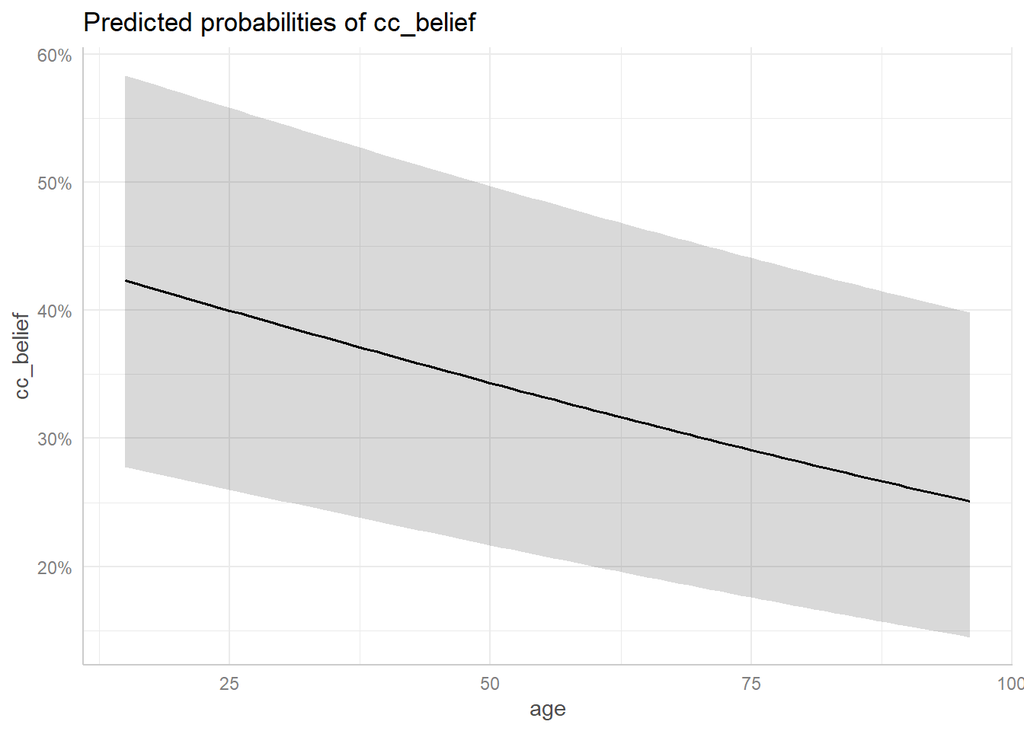

```r
plot(ggpredict(logit.model, terms = "age [all]"))
```

We can try to make a more concise model only with the variables that showed promise in prediction.

```r
logit.model_b <- glm(cc_belief ~
                       cc_real + worry_cc + cc_impact +
                      cc_red_group + taxes_fossil + age + female + edu_years,
                     family = "binomial",
                     data = training)

summary(logit.model_b)
```

```
##
## Call:
## glm(formula = cc_belief ~ cc_real + worry_cc + cc_impact + cc_red_group +
##     taxes_fossil + age + female + edu_years, family = "binomial",
##     data = training)
##
## Coefficients:
##               Estimate Std. Error z value             Pr(>|z|)
## (Intercept)  -2.356812   0.326854  -7.211    0.000000000000557 ***
## cc_real       0.336032   0.068358   4.916    0.000000884394573 ***
## worry_cc      0.315612   0.044906   7.028    0.000000000002090 ***
## cc_impact    -0.165445   0.018009  -9.187 < 0.0000000000000002 ***
## cc_red_group  0.120123   0.016721   7.184    0.000000000000678 ***
## taxes_fossil  0.113504   0.026695   4.252    0.000021194896582 ***
## age          -0.011186   0.002051  -5.455    0.000000048999149 ***
## female1      -0.221318   0.072823  -3.039              0.00237 **
## edu_years     0.018302   0.010069   1.818              0.06912 .
## ---
## Signif. codes:  0 '***' 0.001 '**' 0.01 '*' 0.05 '.' 0.1 ' ' 1
##
## (Dispersion parameter for binomial family taken to be 1)
##
##     Null deviance: 4913.9  on 3568  degrees of freedom
## Residual deviance: 4403.1  on 3560  degrees of freedom
## AIC: 4421.1
##
## Number of Fisher Scoring iterations: 4
```

```r
AIC(logit.model, logit.model_b)
```

```
##               df      AIC
## logit.model   47 4227.641
## logit.model_b  9 4421.142
```

Our reduced model confirms that belief that climate change is real, worry, group responsibility, and support for fossil fuel taxes all significantly increase the likelihood of belief. Age and being female are associated with lower belief, and higher education has a weakly positive effect.

We can again take a closer look at some predictors:

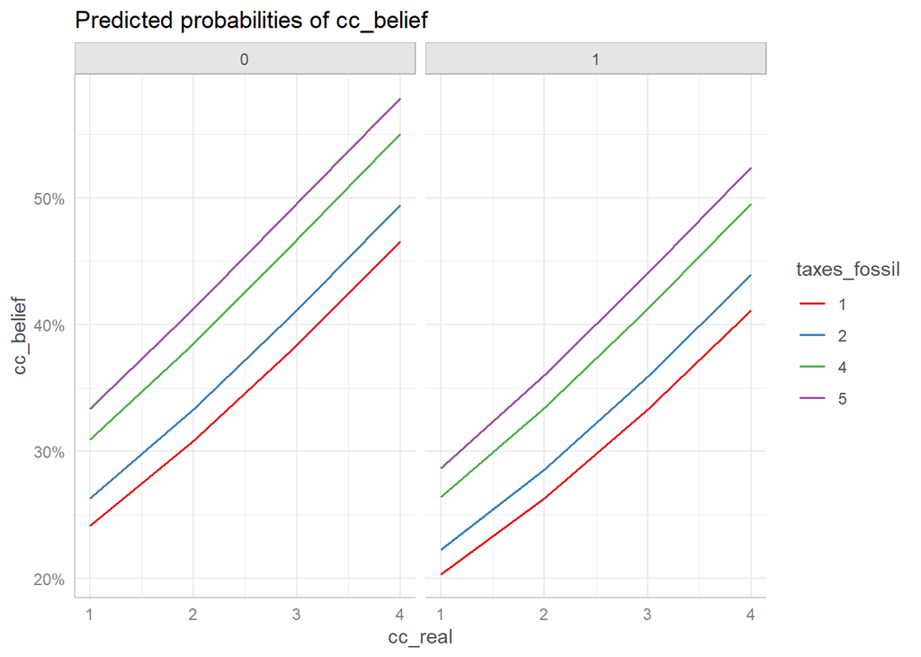

```r
gg.pred <- ggpredict(logit.model_b, terms = c("cc_real", "taxes_fossil", "female"), ci_level = NA)
plot(gg.pred)
```

As belief in the reality of climate change increases (`cc_real`), the predicted probability of believing it is human-caused also increases, particularly for those who support taxing fossil fuels. Men consistently show higher probabilities than women across all values.